# Intro to Data Analysis

This initial project will go through the basics of data analysis using Python. We will be examining a small dataset based off the passengers of the Titanic, consisting of their names, genders, ages, cabin class, ticket cost, where they boarded from, and whether or not they survived the sinking of the ship.

The main question to be addressed in this project will be to see what were the main reasons that some people survived and others did not.

## Project - Investigate a Dataset

Start off by importing required libraries, reading in the csv file, and printing out the names of rows & columns.

```python
import pandas, numpy, matplotlib.pyplot as plt, csv
```

```python
titanic=pandas.read_csv('titanic-data.csv')
titanic.axes
```

```
[RangeIndex(start=0, stop=891, step=1),
 Index([u'PassengerId', u'Survived', u'Pclass', u'Name', u'Sex', u'Age',
        u'SibSp', u'Parch', u'Ticket', u'Fare', u'Cabin', u'Embarked'],
       dtype='object')]
```

The axes attribute tells us the name of the columns, as well as how many rows there are. Now we use the head function to get a look at part of the dataset, followed by the describe function to get some preliminary statistics.

```python
titanic.head()
```

|  | PassengerId | Survived | Pclass | Name | Sex | Age | SibSp | Parch | Ticket | Fare | Cabin | Embarked |
| --- | --- | --- | --- | --- | --- | --- | --- | --- | --- | --- | --- | --- |
| 0 | 1 | 0 | 3 | Braund, Mr. Owen Harris | male | 22.0 | 1 | 0 | A/5 21171 | 7.2500 | NaN | S |
| 1 | 2 | 1 | 1 | Cumings, Mrs. John Bradley (Florence Briggs Th... | female | 38.0 | 1 | 0 | PC 17599 | 71.2833 | C85 | C |
| 2 | 3 | 1 | 3 | Heikkinen, Miss. Laina | female | 26.0 | 0 | 0 | STON/O2. 3101282 | 7.9250 | NaN | S |
| 3 | 4 | 1 | 1 | Futrelle, Mrs. Jacques Heath (Lily May Peel) | female | 35.0 | 1 | 0 | 113803 | 53.1000 | C123 | S |
| 4 | 5 | 0 | 3 | Allen, Mr. William Henry | male | 35.0 | 0 | 0 | 373450 | 8.0500 | NaN | S |

```python
titanic.describe()
```

|  | PassengerId | Survived | Pclass | Age | SibSp | Parch | Fare |
| --- | --- | --- | --- | --- | --- | --- | --- |
| count | 891.000000 | 891.000000 | 891.000000 | 714.000000 | 891.000000 | 891.000000 | 891.000000 |
| mean | 446.000000 | 0.383838 | 2.308642 | 29.699118 | 0.523008 | 0.381594 | 32.204208 |
| std | 257.353842 | 0.486592 | 0.836071 | 14.526497 | 1.102743 | 0.806057 | 49.693429 |
| min | 1.000000 | 0.000000 | 1.000000 | 0.420000 | 0.000000 | 0.000000 | 0.000000 |
| 25% | 223.500000 | 0.000000 | 2.000000 | 20.125000 | 0.000000 | 0.000000 | 7.910400 |
| 50% | 446.000000 | 0.000000 | 3.000000 | 28.000000 | 0.000000 | 0.000000 | 14.454200 |
| 75% | 668.500000 | 1.000000 | 3.000000 | 38.000000 | 1.000000 | 0.000000 | 31.000000 |
| max | 891.000000 | 1.000000 | 3.000000 | 80.000000 | 8.000000 | 6.000000 | 512.329200 |

Now to answer the question itself, what factors influenced surviving? Start by using the corr function to see correlations between each column.

```python
titanic.corr()
```

|  | PassengerId | Survived | Pclass | Age | SibSp | Parch | Fare |
| --- | --- | --- | --- | --- | --- | --- | --- |
| PassengerId | 1.000000 | -0.005007 | -0.035144 | 0.036847 | -0.057527 | -0.001652 | 0.012658 |
| Survived | -0.005007 | 1.000000 | -0.338481 | -0.077221 | -0.035322 | 0.081629 | 0.257307 |
| Pclass | -0.035144 | -0.338481 | 1.000000 | -0.369226 | 0.083081 | 0.018443 | -0.549500 |
| Age | 0.036847 | -0.077221 | -0.369226 | 1.000000 | -0.308247 | -0.189119 | 0.096067 |
| SibSp | -0.057527 | -0.035322 | 0.083081 | -0.308247 | 1.000000 | 0.414838 | 0.159651 |
| Parch | -0.001652 | 0.081629 | 0.018443 | -0.189119 | 0.414838 | 1.000000 | 0.216225 |
| Fare | 0.012658 | 0.257307 | -0.549500 | 0.096067 | 0.159651 | 0.216225 | 1.000000 |

Looking at this table, the Survived row has the highest correlation with the Passenger Class & Fare columns, telling us that the wealthier travellers were the ones that were more likely to survive.

In addition, looking at the Pclass row, the highest correlations are with the Age & Fare columns, indicating that the the wealthier passengers tended to be older as well.

We also see that there were a good amount of families travelling together, not limited to any specific class, indicated by the correlation between the Sibling/Spouse & Parent/Child columns.

```python
# Statistics of the Survivors sorted by Passenger Class
titanic.groupby('Pclass').describe()['Survived']
```

| Pclass | count | mean | std | min | 25% | 50% | 75% | max |
| --- | --- | --- | --- | --- | --- | --- | --- | --- |
| 1 | 216.0 | 0.629630 | 0.484026 | 0.0 | 0.0 | 1.0 | 1.0 | 1.0 |
| 2 | 184.0 | 0.472826 | 0.500623 | 0.0 | 0.0 | 0.0 | 1.0 | 1.0 |
| 3 | 491.0 | 0.242363 | 0.428949 | 0.0 | 0.0 | 0.0 | 0.0 | 1.0 |

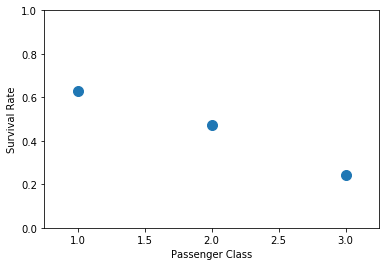

```python
# Graph showing average percent of survivors for each class
plt.plot(titanic.groupby('Pclass').mean()['Survived'], 'o', ms=10)
plt.xlabel('Passenger Class')
plt.ylabel('Survival Rate')
plt.axis([0.75, 3.25, 0, 1])
plt.show()
```

```python
# Statistics of the ticket costs sorted by Passenger Class
titanic.groupby('Pclass').describe()['Fare']
```

| Pclass | count | mean | std | min | 25% | 50% | 75% | max |
| --- | --- | --- | --- | --- | --- | --- | --- | --- |
| 1 | 216.0 | 84.154687 | 78.380373 | 0.0 | 30.92395 | 60.2875 | 93.5 | 512.3292 |
| 2 | 184.0 | 20.662183 | 13.417399 | 0.0 | 13.00000 | 14.2500 | 26.0 | 73.5000 |
| 3 | 491.0 | 13.675550 | 11.778142 | 0.0 | 7.75000 | 8.0500 | 15.5 | 69.5500 |

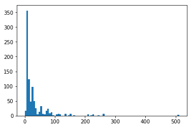

```python
# Histogram of ticket costs
plt.hist(titanic['Fare'], bins=89)
plt.show()
```

```python
# Statistics of the ages of the passengers sorted by their class
titanic.groupby('Pclass').describe()['Age']
```

| Pclass | count | mean | std | min | 25% | 50% | 75% | max |
| --- | --- | --- | --- | --- | --- | --- | --- | --- |
| 1 | 186.0 | 38.233441 | 14.802856 | 0.92 | 27.0 | 37.0 | 49.0 | 80.0 |
| 2 | 173.0 | 29.877630 | 14.001077 | 0.67 | 23.0 | 29.0 | 36.0 | 70.0 |
| 3 | 355.0 | 25.140620 | 12.495398 | 0.42 | 18.0 | 24.0 | 32.0 | 74.0 |

The above three tables support what was seen in the correlations table.

The first table shows that the highest percentages of survivors, at 63%, were First class, 47% in Second class, and only 24% of the Third class passengers survived the sinking of the ship.

The second table shows that First class tickets were significantly higher in cost than the lower class tickets.

Notcing that there are some entries missing for the ages, the third table affirms that the wealthier passengers tended to be older.

The information in the data seems to be enough to tell us that the largest contributing factor to surviving the Titanic accident was wealth & passenger class. Even amongst these survivors, it is possible that location of the cabin and location at the time of the incident would have made a difference in whether they were able to make it off the ship in time.